# High-performance computing for Economists: Parallel processing

Lars Vilhuber, based on previous presentation by Kevin McKinney  
2015/8/17-2015/8/19

### Why parallel processing?

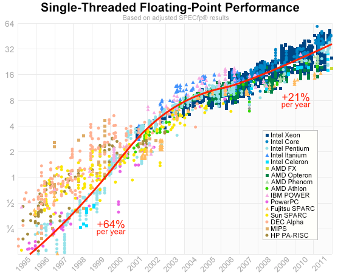

Single-core performance growth has slowed. More cost-effective to add multiple cores.

### Threads vs processes

Both can be used for parallel processing

- A process can launch multiple threads
  - Threads run only on the same node
  - Threads run within a process and have access to the memory and resources of that process
- A user or program can launch multiple processes (same or different node) and communicate via IPC or MPI
- Different tools for working with threads and processes, although the goal is the same

### Parallel execution

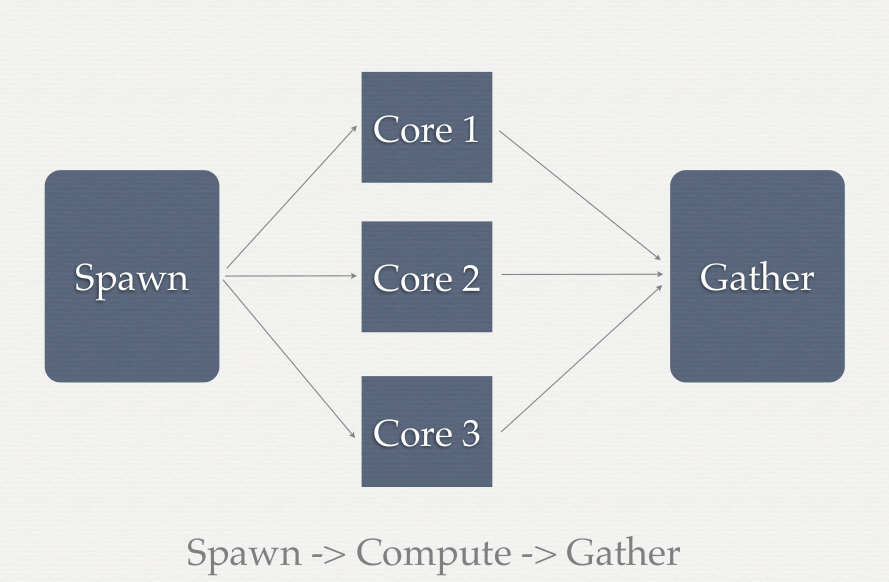

… or “map-reduce”…

### Benefits vs costs

Using cores can potentially do more work

But

- Each core needs access to the data (spawn)
- Each core needs to output results (gather)
- Additional programming and processing time required to implement solution in parallel

### Dependencies

- Can you break the entire compute problem into independent chunks
  - Yes - potential candidate for parallel execution
  - No - not all of it
  - Identify the portions of the code that do not have dependencies
- The benefits of parallelization depend directly on the time spent executing parallel code

### Amdahl's law

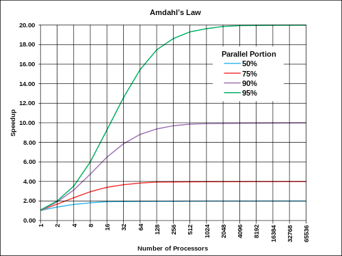

\[ \lim_{P \to \inf} \frac{1}{\frac{1-\alpha}{P} + \alpha} = \frac{1}{\alpha} \]

### Example problem

Calculate the column means of a data matrix

- Divide data into equal groups (blocks) of rows for parallel processing (spawn)
  - Is the array in memory or does it need to be read from disk?
  - Memory access is an order of magnitude faster than disk access
  - … but has more limits
- Within each group, calculate the sum of each column
  - Store result (what if one core wants to write the result at the same time as another core?)
- Sum the results for each group and divide the total sample size

### Example (continued)

- Or: process only a single column at a time (column-store databases!)
- In general, if the groups are
  - large
  - numerous
  - amount of processing time for each group is high
- then it is worthwhile to execute in parallel

### Considerations

Both programming time and processing time should be considered when deciding on structure of program

- Carefule tuning of single-threaded application may be a better investment
- Does your program take days or weeks to find a solution?
- How often do you expect to run the code? Before implementing a parallel solution, spend time assessing the expected benefit

### Implicit vs Explicit

Not necessarily a custom solution - switching software may also be worthwhile

- SAS, Stata, Matlab have internal parallel algorithms that will do much if not all of the hard work for you
  - they will spawn the threads and gather the results using well-tested routines
  - Your job is to manage the number of threads
- Programs assume all threads on a core are available to you (or limited by license)
  - On a large node, not always efficient
  - On a shared system, not allowed!

### Taking control of implicit threads

- SAS
  - `THREADS` and `CPUCOUNT=X`
  - `NOTHREADS`
- Stata
  - `set processors X`
- Matlab
  - `-singleCompThread` (may not be exact)

### Explicit processes: PBS-like

PBS-like systems allow you spawn jobs automatically

- `qsub -t 1-100%5 script.qsub` runs 5 jobs at a time, from 1-100
- `$PBS_ARRAYID` is provided to the script, and can be used to pass to the program, for instance
  - SAS

```
%let sample=%sysget(PBS_ARRAYID);
data one;
  set LIBRARY.bigdata(where=(mod(_n_,100)=&sample.));
  run;
```

- Similar in R, Matlab, Stata

### Explicit processes: PBS-like, Stata

```
local arrayid : env PBS_ARRAYID
use if sample == `arrayid' \\
   using ${LIBRARY}/bigdata
```

would read in only the records for which the (previously created) variable `sample` is equal to the PBS_ARRAYID.

### Explicit processes

Conditional execution

```
JOB_ID_1=$(qsub 01_script.sh)
JOB_ID_2=$(qsub -W depend=afterok:$JOB_ID_1 02_script.sh)
JOB_ID_3=$(qsub -W depend=afterok:$JOB_ID_2 03_script.sh)
```

### Live demo

For instance, try

- 2-dopar.R

### Parallel processing

Computing with 11 cores (and R version 4.0.2 (2020-06-22) )

```r
library(doParallel)
source("https://labordynamicsinstitute.github.io/computing4economists/programs/day2/2-dopar.R", echo=TRUE)
```

### Parallel processing: results

```
> library(doParallel)

> ncpus <- detectCores()

> ncpus <- as.numeric(ncpus) - 1

> ncpus
[1] 11

> cl <- makeCluster(ncpus)

> registerDoParallel(cl)

> x <- iris[which(iris[, 5] != "setosa"), c(1, 5)]

> trials <- 10000

> ptime <- system.time({
+     r <- foreach(icount(trials), .combine = cbind) %dopar% {
+         ind <- sample(100, 100, replace = TRUE)
+         re .... [TRUNCATED]

> ptime
elapsed
   7.25
```

### Parallel processing: results

- Computing with 11 cores (and R version 4.0.2 (2020-06-22)):

7.25 seconds

### Parallel processing on ECCO: results

- Computing with 1 core on ECCO (compute-0-4, R 3.0): 38.955 seconds (source)
- Computing with 4 cores on ECCO (compute-0-4, R 3.2): 13.859 seconds
- Computing with 8 cores on ECCO (compute-0-4, R 3.2): 8.319 seconds
- Computing with 16 cores on ECCO (compute-0-4, R 3.2): 6.111 seconds
- Computing with 32 cores on ECCO (compute-0-4, R 3.0): 5.089 seconds (source)

### Sources for live demonstration

- 0-loadlibs.R: program submitted on ECCO
- dopar.qsub: qsub program submitted on ECCO calling the R program above
- test2.sas: SAS program to illustrate some points (submitted using qsas)
- test.sas and test.qsub: programs to demonstrate use of PBS_ARRAY_ID functionality